# Análisis de hechos delictivos - énfasis PNC Parte 2

# Librerias

```r
if (!require(dplyr)) install.packages("dplyr")
library(dplyr)

#trees
if (!require(rpart)) install.packages("rpart")
library(rpart)

if (!require(rpart.plot)) install.packages("rpart.plot")
library(rpart.plot)

#randomforest
if (!require(randomForest)) install.packages("randomForest")
library(randomForest)
```

# Carga de información y limpieza de datos

Los siguientes años seran descartados, ya que no se cuenta con una base de datos para su análisis

- 2009
- 2010
- 2013
- 2014
- 2015

También es importante comentar que la información que se necesita ya se ha verificado y limpiado en el proyecto anterior, por lo que se ha escrito en archivos csv, tanto para detenidos como para víctimas para así cargarlo de manera sencilla en esta parte 2 del proyecto.

```r
#carga de informacion
detenidos_data  <- read.csv("../data/detenidos.csv", sep = ",")
victimas_data  <- read.csv("../data/victimas.csv",  sep = ",")
```

# 1. Predicción por medio de árboles de decisión

### 1.1 Predicción del año de ocurrencia de detención

El siguiente arbol de decisión toma como variables independendientes a área_geo_ocu(1= Urbano, 2=Rural, 9=Ignorado), delito_com(valores de 1 a 68) y menor_mayor(1 = Mayor de edad, 2 = Menor de edad, 9 = Ignorado) con el fin de predecir el año de detención de la persona que cometió el delito(2016,2017,2019,2020)

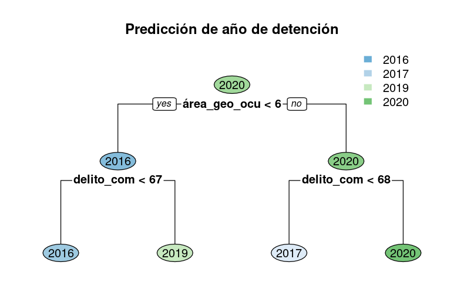

```r
#1 Apriori
detenidosf1 <- detenidos_data %>%
  filter(año_ocu %in% c(2016,2017,2019,2020) )


arbol1 <- rpart(año_ocu ~
               área_geo_ocu+
               delito_com+
               menor_mayor,
               data = detenidosf1, method = "class");


rpart.plot(arbol1, type=2, extra=0, under = TRUE, fallen.leaves = TRUE, box.palette = "BuGn",
           main ="Predicción de año de detención", cex = 1)
```

```r
NA
NA
```

```r
#Pruebas
# La detención ocurrion en el área urbana, el delito fue homicidio por arma de fuego y el detenido era mayor de edad.
anio_detencion1 <- data.frame(
  área_geo_ocu = c(1),
  delito_com = c(1),
  menor_mayor = c(1)
)

#  predicción
resultado <- predict(arbol1, anio_detencion1, type = "class")
print(resultado)
```

```
   1
2016
Levels: 2016 2017 2019 2020
```

```r
# La detención ocurrion en el área rural, el delito fue juegos ilícitos y el detenido era mayor de edad.
anio_detencion2 <- data.frame(
  área_geo_ocu = c(2),
  delito_com = c(67),
  menor_mayor = c(1)
)

#  predicción
resultado2 <- predict(arbol1, anio_detencion2, type = "class")
print(resultado2)
```

```
   1
2019
Levels: 2016 2017 2019 2020
```

```r
# La detención ocurrion en un área desconocida, el delito fue agresión y el detenido era mayor de edad.
anio_detencion3 <- data.frame(
  área_geo_ocu = c(9),
  delito_com = c(12),
  menor_mayor = c(1)
)

#  predicción
resultado3 <- predict(arbol1, anio_detencion3, type = "class")
print(resultado3)
```

```
   1
2017
Levels: 2016 2017 2019 2020
```

```r
# La detención ocurrio en un área desconocida, el delito fue agresión y el detenido era mayor de edad.
anio_detencion4 <- data.frame(
  área_geo_ocu = c(9),
  delito_com = c(12),
  menor_mayor = c(1)
)

#  predicción
resultado4 <- predict(arbol1, anio_detencion4, type = "class")
print(resultado4)
```

```
   1
2017
Levels: 2016 2017 2019 2020
```

### 1.2 Predicción de grupo de hora de ocurrencia de delito

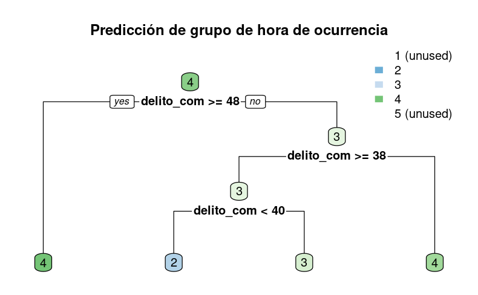

```r
#2 apriori
arbol2 <- rpart(g_hora ~
               delito_com,
               data = detenidos_data, method = "class");


rpart.plot(arbol2, type=2, extra=0, under = TRUE, fallen.leaves = TRUE, box.palette = "BuGn",
           main ="Predicción de grupo de hora de ocurrencia", cex = 1)
```

```r
#Pruebas
# Dado que el delito fue homicidio por arma de fuego
grupo_h_ocu1 <- data.frame(
  delito_com = c(1)
)

#  predicción
resultado_h1 <- predict(arbol2, grupo_h_ocu1, type = "class")
print(resultado_h1)
```

```
1
4
Levels: 1 2 3 4 5
```

```r
#Pruebas
# Dado que el delito fue secuestro
grupo_h_ocu2 <- data.frame(
  delito_com = c(15)
)

#  predicción
resultado_h2 <- predict(arbol2, grupo_h_ocu2, type = "class")
print(resultado_h2)
```

```
1
4
Levels: 1 2 3 4 5
```

### 1.3 Predicción de edad de la persona que fue víctima de un delito cuando es menor de edad

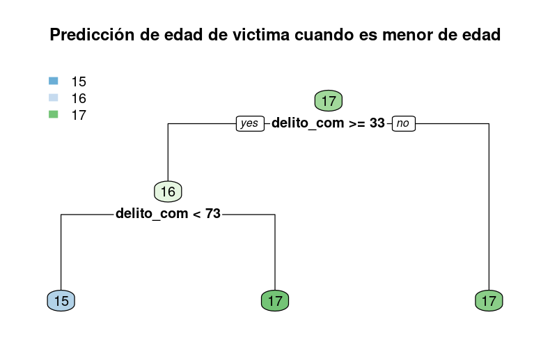

```r
victimasFpg_f2 <- victimas_data %>%
  filter(edad_per %in% c(15,16,17)) %>%
  select(-menor_mayor)

arbol3 <- rpart(edad_per ~
               delito_com,
               data = victimasFpg_f2, method = "class")


rpart.plot(arbol3, type=2, extra=0, under = TRUE, fallen.leaves = TRUE, box.palette = "BuGn",
           main ="Predicción de edad de victima cuando es menor de edad", cex = 1)
```

```r
#Pruebas
# Dado que el delito fue robo a buses extraurbanos
edad1 <- data.frame(
  delito_com = c(33)
)

#  predicción
resultado_edad1 <- predict(arbol3, edad1, type = "class")
print(resultado_edad1)
```

```
 1
15
Levels: 15 16 17
```

```r
#Pruebas
# Dado que el delito fue Homicidio por arma de fuego
edad2 <- data.frame(
  delito_com = c(1)
)

#  predicción
resultado_edad2 <- predict(arbol3, edad2, type = "class")
print(resultado_edad2)
```

```
 1
17
Levels: 15 16 17
```

```r
#Pruebas
# Dado que el delito fue Extorsión a comercios
edad3 <- data.frame(
  delito_com = c(97)
)

#  predicción
resultado_edad3 <- predict(arbol3, edad3, type = "class")
print(resultado_edad3)
```

```
 1
17
Levels: 15 16 17
```

### 1.4 Predicción del sexo de la persona que fue víctima de un delito

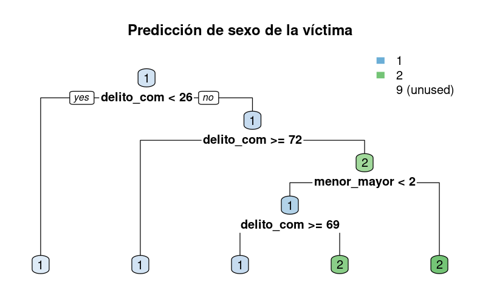

```r
#Propio (sexo de la victima)
arbol4 <- rpart(sexo_per ~
               delito_com +
               menor_mayor,
               data = victimas_data, method = "class");


rpart.plot(arbol4, type=2, extra=0, under = TRUE, fallen.leaves = TRUE, box.palette = "BuGn",
           main ="Predicción de sexo de la víctima", cex = 1)
```

```r
#Pruebas
# Dado que el delito fue robo de motococletas siendo mayor de edad
sexo1 <- data.frame(
  delito_com = c(24),
  menor_mayor = c(1)
)

#  predicción
resultado_s1 <- predict(arbol4, sexo1, type = "class")
print(resultado_s1)
```

```
1
1
Levels: 1 2 9
```

# 2. Predicción por medio de bosques aleatorios

### 2.1 Predicción del año de ocurrencia de detención

El bosque aleatorio toma como variables independendientes a área_geo_ocu(1= Urbano, 2=Rural, 9=Ignorado), delito_com(valores de 1 a 68) y menor_mayor(1 = Mayor de edad, 2 = Menor de edad, 9 = Ignorado) con el fin de predecir el año de detención de la persona que cometió el delito(2016,2017,2019,2020)

```r
#Regla apriori 1, anio de detencion
detenidosf1_rf <- detenidos_data %>%
  filter(año_ocu %in% c(2016,2017,2019,2020) )

detenidosf1_rf$año_ocu <- as.factor(detenidosf1_rf$año_ocu)

set.seed(100)

detenidosf1_rf <- detenidosf1_rf[sample(1:nrow(detenidosf1_rf)),]

#entreno de 80% y restante para predicciones
index <- sample(1:nrow(detenidosf1_rf), 0.8*nrow(detenidosf1_rf))
train_rf1 <- detenidosf1_rf[index,]
train_rf1 <- na.omit(train_rf1)


test_rf1 <- detenidosf1_rf[-index,]
test_rf1 <- na.omit(test_rf1)

#entrenando
forest1 <- randomForest(año_ocu ~
               área_geo_ocu+
               delito_com+
               menor_mayor,
               data = train_rf1, ntree = 100, mtry = 3)

#probando data test
training <- predict(forest1, test_rf1)


#Revisando precision
matriz <- table(test_rf1$año_ocu, training)
pre <- sum(diag(matriz)) / sum(matriz)

print(matriz)
```

```
      training
        2016  2017  2019  2020
  2016 10155     0  4429     0
  2017     0  8806     0  4434
  2019  3816     0  9089     0
  2020     0  3445     0 15335
```

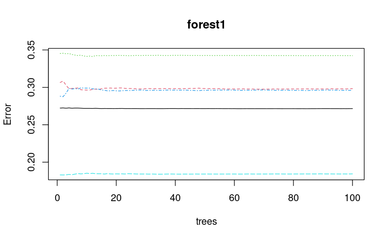

```r
#Grafincado Arboles
plot(forest1)
```

```r
#Pruebas
#Predecir año de detención basado en el área goográfica urbana, el delito homicidio por arma de fuego siendo menor de edad
new_dataf1_1 <- data.frame(
              área_geo_ocu=1,
               delito_com=1,
               menor_mayor=2
)


predictionf1_1 <-predict(forest1, new_dataf1_1)
print(predictionf1_1)
```

```
   1
2019
Levels: 2016 2017 2019 2020
```

```r
#Predecir año de detención basado en el área goográfica urbana, el delito extorsion siendo el dtenido mayor de edad
new_dataf1_2 <- data.frame(
              área_geo_ocu=2,
               delito_com=40,
               menor_mayor=1
)


predictionf1_2 <-predict(forest1, new_dataf1_2)
print(predictionf1_2)
```

```
   1
2016
Levels: 2016 2017 2019 2020
```

### 2.2 Predicción del sexo de la persona que fue víctima de un delito

```r
#select data, sexo de victimas
victimas_rf2 <- victimas_data;

victimas_rf2$sexo_per <- as.factor(victimas_rf2$sexo_per)

set.seed(100)

victimas_rf2 <- victimas_rf2[sample(1:nrow(victimas_rf2)),]

#entreno de 80% y restante para predicciones
index <- sample(1:nrow(victimas_rf2), 0.8*nrow(victimas_rf2))
train_rf2 <- victimas_rf2[index,]
train_rf2 <- na.omit(train_rf2)


test_rf2 <- victimas_rf2[-index,]
test_rf2 <- na.omit(test_rf2)


#entrenando
forest2 <- randomForest(sexo_per ~
               delito_com +
               menor_mayor,
               data = train_rf2, ntree = 100, mtry = 2)

#probando data test
training2 <- predict(forest2, test_rf2)

#Revisando precision
matriz2 <- table(test_rf2$sexo_per, training2)
pre2 <- sum(diag(matriz2)) / sum(matriz2)

print(matriz2)
```

```
   training2
        1     2     9
  1 28379  1335     4
  2  9860  3085     0
  9   232    10     0
```

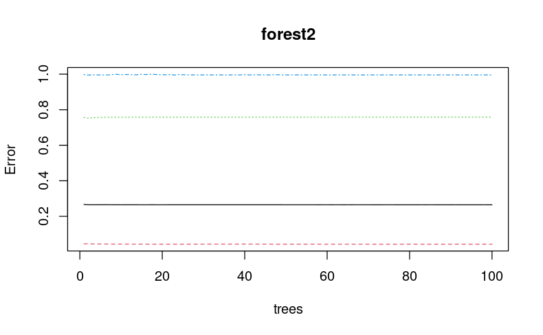

```r
#Grafincado Arboles
plot(forest2)
```

```r
#Predecir el sexo de la víctima dado que el delito cometido es homicidio por arma de fuego, siendo la víctima mayor de edad
new_dataf2_1 <- data.frame(
              delito_com=1,
              menor_mayor=1
)


predictionf2_1 <-predict(forest2, new_dataf2_1)
print(predictionf2_1)
```

```
1
1
Levels: 1 2 9
```

```r
#Predecir el sexo de la víctima dado que el delito cometido es hurto a peatones , siendo la víctima menor de edad
new_dataf2_2 <- data.frame(
              delito_com=80,
              menor_mayor=2
)


predictionf2_2 <-predict(forest2, new_dataf2_2)
print(predictionf2_2)
```

```
1
2
Levels: 1 2 9
```